# Abalone

# Cel zadania

Celem zadania jest przygotowanie modelu uczenia maszynowego służącego do przewidywania wieku uchowców na podstawie pomiarów fizycznych. W tym celu zgromadzono dane w ilości 4177 obserwacji, w tym 8 predyktorów i jedna zmienna wynikowa.

## Analiza opisowa

Aby przystąpić do budowania modelu należy dokonać analizy opisowej poszczególnych predyktorów oraz zmiennej wynikowej.

```r
library(tidyverse)
library(skimr)
library(gt)

df <- read_csv("abalone.csv")
df <- df[,-1]

df |>
  skim()
```

Data summary

| Name | df |
| --- | --- |
| Number of rows | 4177 |
| Number of columns | 9 |
| _______________________ |  |
| Column type frequency: |  |
| character | 1 |
| numeric | 8 |
| ________________________ |  |
| Group variables | None |

**Variable type: character**

| skim_variable | n_missing | complete_rate | min | max | empty | n_unique | whitespace |
| --- | --- | --- | --- | --- | --- | --- | --- |
| sex | 0 | 1 | 1 | 1 | 0 | 3 | 0 |

**Variable type: numeric**

| skim_variable | n_missing | complete_rate | mean | sd | p0 | p25 | p50 | p75 | p100 | hist |
| --- | --- | --- | --- | --- | --- | --- | --- | --- | --- | --- |
| length | 0 | 1 | 0.52 | 0.12 | 0.07 | 0.45 | 0.54 | 0.62 | 0.81 | ▁▂▅▇▂ |
| diameter | 0 | 1 | 0.41 | 0.10 | 0.06 | 0.35 | 0.42 | 0.48 | 0.65 | ▁▂▆▇▁ |
| height | 0 | 1 | 0.14 | 0.04 | 0.00 | 0.12 | 0.14 | 0.16 | 1.13 | ▇▁▁▁▁ |
| whole_weight | 0 | 1 | 0.83 | 0.49 | 0.00 | 0.44 | 0.80 | 1.15 | 2.83 | ▇▇▅▁▁ |
| shucked_weight | 0 | 1 | 0.36 | 0.22 | 0.00 | 0.19 | 0.34 | 0.50 | 1.49 | ▇▇▂▁▁ |
| viscera_weight | 0 | 1 | 0.18 | 0.11 | 0.00 | 0.09 | 0.17 | 0.25 | 0.76 | ▇▇▂▁▁ |
| shell_weight | 0 | 1 | 0.24 | 0.14 | 0.00 | 0.13 | 0.23 | 0.33 | 1.00 | ▇▇▂▁▁ |
| number_of_rings | 0 | 1 | 9.93 | 3.22 | 1.00 | 8.00 | 9.00 | 11.00 | 29.00 | ▁▇▂▁▁ |

Aby sprawdzić częstość występowania poszczególnych płci wykreślono wykres słupkowy.

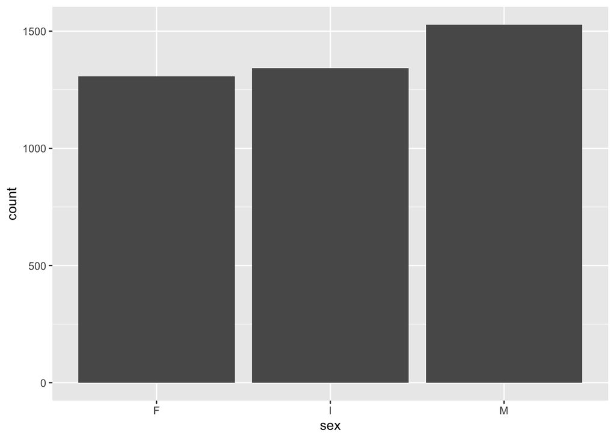

```r
df |>
  ggplot(aes(sex))+
  geom_bar()
```

Jak widać mamy w miarę zbalansowaną zmienną płci. Dla zilustrowania rozkładów zmiennych ilościowych wykorzystamy histogramy.

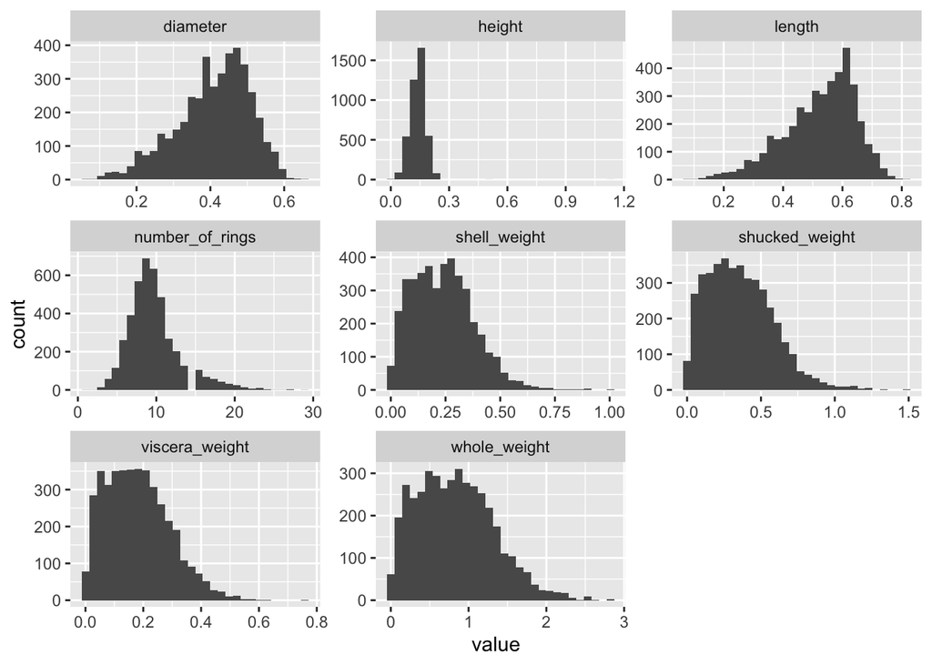

```r
df |>
  pivot_longer(cols = where(is.numeric)) |>
  ggplot(aes(x = value))+
  geom_histogram()+
  facet_wrap(~name, scales= "free")
```

Jak widać z powyższych wykresów część zmiennych charakteryzuje się prawostronną asymetrią (jak zmienna zależna oraz zmienne wyrażające wagę), natomiast zmienne takie jak `diameter` i `length` mają asymetrię lewostronną. Dla lepszego działania modeli jądrowych takich jak SVM proponuję transformację zmiennych do rozkładów normalnych.

Sprawdzone zostaną również korelacje pomiędzy zmiennymi.

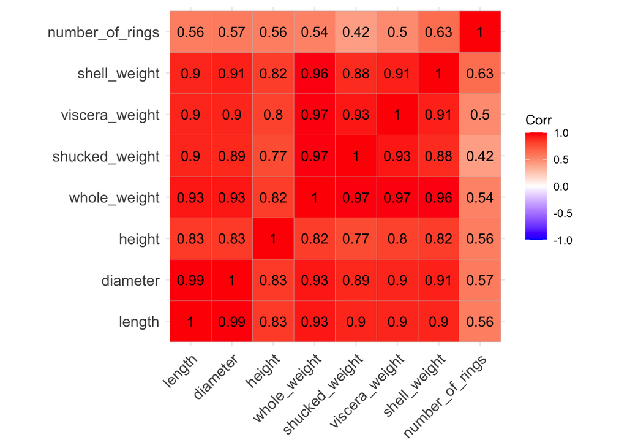

```r
library(ggcorrplot)
r <- df |>
  select(-sex) |>
  cor()
p <- df |>
  select(-sex) |>
  cor_pmat()

ggcorrplot(r, hc.order = F, lab = T, p.mat = p)
```

Pobieżna analiza wyników macierzy korelacji każe się domyślać, że zależności pomiędzy predyktoramy są ściśle liniowe. W związku z tym trzeba się poważnie zastanowić nad usunięciem tych nadmiarowości (niektóre korelacje sięgają 0.99). Ponieważ macierz korelacji pokazuje związki liniowe, to do redukcji nadmiarowości mozna użyć PCA.

## Przygotowanie danych

W kolejnych korkach preprocessingu podzielimy dane na zbiór uczący i testowy, dokonamy transformacji rozkładów predyktorów do rozkładu normalnego, standaryzacji predyktorów oraz redukcji wymiarów do tylu składowych aby poziom wyjaśnionej wariancji wynosił co najmniej 95%. Ponieważ planuję sprawdzić cztery modele, a każdy z nich wymaga nieco innego preprocessingu, to przygotuję różne formuły transformacji danych - odpowiednie dla poszczególnych modeli.

```r
library(tidymodels)
library(bestNormalize)
library(multilevelmod)
library(poissonreg)
library(agua)

set.seed(44)
split <- initial_split(df, prop = 0.8, strata = "number_of_rings")
df_train <- training(split)
df_test <- testing(split)

base_rec <- recipe(number_of_rings ~ ., data = df_train)

# do modelu null nie potrzeba nic więcej
rec_null <- base_rec |>
  step_dummy(sex)

rec_rf <- base_rec |>
  step_pca(all_numeric_predictors(), threshold = 0.95)

rec_svm <- base_rec |>
  step_best_normalize(all_numeric_predictors()) |>
  step_pca(all_numeric_predictors()) |>
  step_normalize(all_numeric_predictors())

rec_pois <- rec_svm |>
  step_dummy(sex)
```

## Budowa modelu

Najpierw wyznaczymy tzw. linię bazową (lub model bazowy), która oznacza model przewidujący zmienną wynikową jako średnią zmiennej `number_of_rings`. Używa się tego modelu do sprawdzenia czy modele uczenia maszynowego faktycznie przewyższają dopasowaniem model bazowy. Tylko wtedy warto je rozważać.

Do oceny jakości dopasowania użyjemy dwóch miar RMSE i R<sup>2</sup>. Oceny dopasowania dokonamy z wykorzystaniem sprawdzianu krzyżowego 10-krotnego bez powtórzeń.

```r
set.seed(44)
folds <- vfold_cv(df_train, v = 10)

metric <- metric_set(rmse, rsq)

null_regression <- null_model() |>
  set_mode("regression") |>
  set_engine("parsnip")

null_wf <- workflow() |>
  add_recipe(rec_null) |>
  add_model(null_regression)

# w przypadku modelu, który zwraca tylko 1 wartość nie da się policzyć r2
null_res <- fit_resamples(null_wf, resamples = folds, metrics = metric_set(rmse))

collect_metrics(null_res)
```

```
# A tibble: 1 × 6
  .metric .estimator  mean     n std_err .config
  <chr>   <chr>      <dbl> <int>   <dbl> <chr>
1 rmse    standard    3.20    10  0.0693 Preprocessor1_Model1
```

```r
svm <- svm_rbf(mode = "regression",
               engine = "kernlab")

rf <- rand_forest(mode = "regression",
                  engine = "ranger")

pois <- poisson_reg(mode = "regression",
                    engine = "glm")

models <- workflow_set(preproc = list(rec_svm, rec_rf, rec_pois),
                       models = list(svm = svm, rf=rf, pois=pois),
                       cross = F)
models
```

```
# A workflow set/tibble: 3 × 4
  wflow_id      info             option    result
  <chr>         <list>           <list>    <list>
1 recipe_1_svm  <tibble [1 × 4]> <opts[0]> <list [0]>
2 recipe_2_rf   <tibble [1 × 4]> <opts[0]> <list [0]>
3 recipe_3_pois <tibble [1 × 4]> <opts[0]> <list [0]>
```

```r
models <-
  models %>%
  workflow_map("fit_resamples",
               # Options to `workflow_map()`:
               verbose = TRUE,
               # Options to `fit_resamples()`:
               resamples = folds,
               metrics = metric)

collect_metrics(models)
```

```
# A tibble: 6 × 9
  wflow_id      .config     preproc model .metric .estimator  mean     n std_err
  <chr>         <chr>       <chr>   <chr> <chr>   <chr>      <dbl> <int>   <dbl>
1 recipe_1_svm  Preprocess… recipe  svm_… rmse    standard   2.22     10  0.0406
2 recipe_1_svm  Preprocess… recipe  svm_… rsq     standard   0.531    10  0.0155
3 recipe_2_rf   Preprocess… recipe  rand… rmse    standard   2.59     10  0.0544
4 recipe_2_rf   Preprocess… recipe  rand… rsq     standard   0.348    10  0.0107
5 recipe_3_pois Preprocess… recipe  pois… rmse    standard   2.32     10  0.0460
6 recipe_3_pois Preprocess… recipe  pois… rsq     standard   0.488    10  0.0164
```

Model SVM okazał się najlepszy do tego zadania spośród modeli, które były testowane. Jednocześnie należy zaznaczyć, że przewyższa jakością dopasowania model bazowy. W dalszej części będziemy się starali optymalizować parametry modelu. Do optymalizacji wykorzystamy metodę bayesowską.

## Tuning modelu

```r
svm <- svm_rbf(mode = "regression",
               engine = "kernlab",
               cost = tune(),
               rbf_sigma = tune(),
               margin = tune())

# wszystkie parametry są gotowe do tuningu
svm_param <- extract_parameter_set_dials(svm)
svm_param
```

```
Collection of 3 parameters for tuning

 identifier      type    object
       cost      cost nparam[+]
  rbf_sigma rbf_sigma nparam[+]
     margin    margin nparam[+]
```

```r
svm_wf <- workflow() |>
  add_recipe(rec_svm) |>
  add_model(svm)
```

```r
library(doParallel)
cl <- makePSOCKcluster(4)
registerDoParallel(cl)

set.seed(44)
svm_bo <-
  svm_wf |>
  tune_bayes(
    resamples = folds,
    metrics = metric,
    initial = 4,
    param_info = svm_param,
    iter = 25
  )

stopCluster(cl)
saveRDS(svm_bo, "svm_bo.rds")
```

Poniżej można zobaczyć miarę dopasowania w zależności od poszczególnych zestawów parametrów.

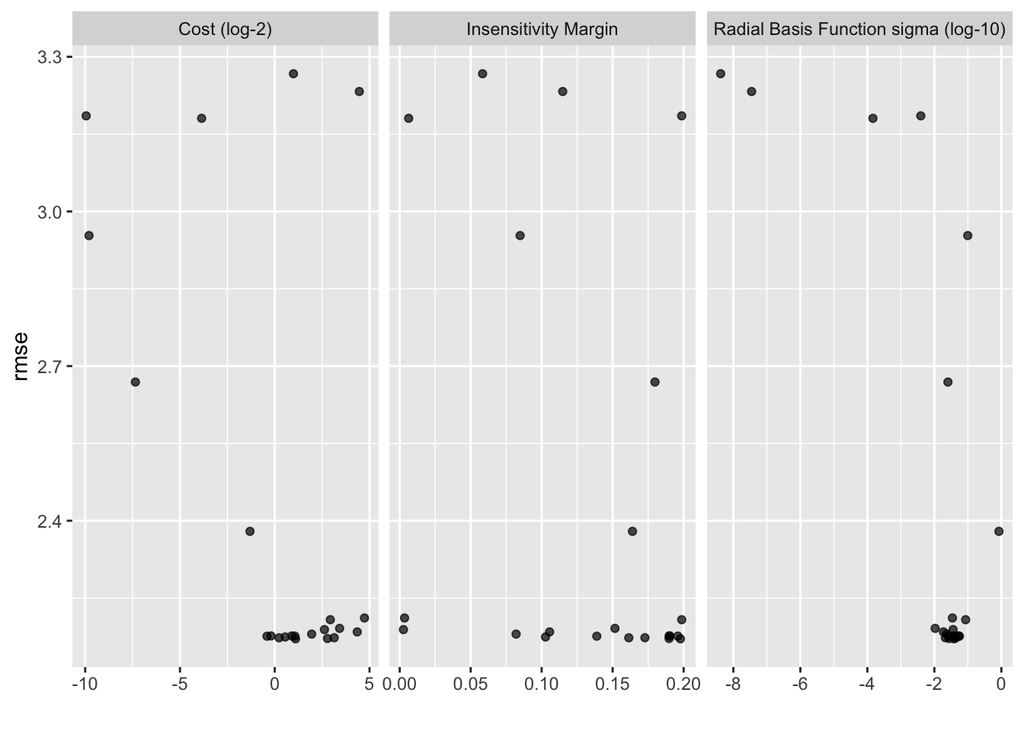

```r
svm_bo <- readRDS("svm_bo.rds")
autoplot(svm_bo, type = 'marginals', metric = 'rmse')
```

I jeszcze jak to się zmieniało w kolejnych iteracjach.

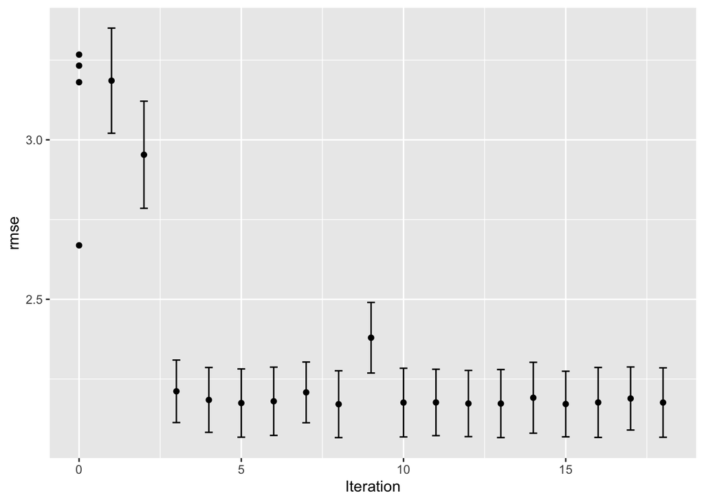

```r
autoplot(svm_bo, type = 'performance', metric = 'rmse')
```

```r
show_best(svm_bo)
```

```
# A tibble: 5 × 10
   cost rbf_sigma margin .metric .estimator  mean     n std_err .config .iter
  <dbl>     <dbl>  <dbl> <chr>   <chr>      <dbl> <int>   <dbl> <chr>   <int>
1  2.14    0.0385  0.198 rmse    standard    2.17    10  0.0470 Iter8       8
2  6.87    0.0274  0.190 rmse    standard    2.17    10  0.0462 Iter15     15
3  1.17    0.0440  0.161 rmse    standard    2.17    10  0.0479 Iter13     13
4  8.80    0.0213  0.173 rmse    standard    2.17    10  0.0466 Iter12     12
5  1.46    0.0355  0.103 rmse    standard    2.17    10  0.0480 Iter5       5
```

Najlepsza okazała się kombinacja: `cost=2.14`, `rbf_sigma=0.0385`, `margin=0.198`. Taką kombinację użyjemy do uczenia ostatecznego modelu.

## Ocena dopasowania modelu końcowego

```r
best_params <- select_best(svm_bo, metric = "rmse")

final_wf <- svm_wf |>
  finalize_workflow(best_params)

final_wf
```

```
══ Workflow ════════════════════════════════════════════════════════════════════
Preprocessor: Recipe
Model: svm_rbf()

── Preprocessor ────────────────────────────────────────────────────────────────
3 Recipe Steps

• step_best_normalize()
• step_pca()
• step_normalize()

── Model ───────────────────────────────────────────────────────────────────────
Radial Basis Function Support Vector Machine Model Specification (regression)

Main Arguments:
  cost = 2.13845526716154
  rbf_sigma = 0.038534072852543
  margin = 0.197734726890093

Computational engine: kernlab
```

```r
final_fit <- final_wf |>
  last_fit(split)

final_fit$.metrics
```

```
[[1]]
# A tibble: 2 × 4
  .metric .estimator .estimate .config
  <chr>   <chr>          <dbl> <chr>
1 rmse    standard       2.14  Preprocessor1_Model1
2 rsq     standard       0.591 Preprocessor1_Model1
```

Jak widać model został poprawiony w stosunku do modelu SVM z domyślnymi parametrami.

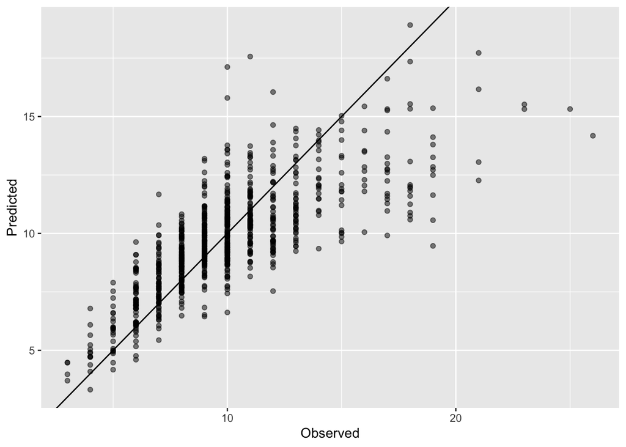

```r
final_fit$.predictions[[1]] |>
  ggplot(aes(x = number_of_rings, y = .pred))+
  geom_point(alpha=0.5)+
  geom_abline(slope = 1, intercept = 0)+
  labs(y = "Predicted", x = "Observed")
```

Widać, że model niedoszacowuje wartości dla większej liczby ringów. Można spróbować poradzić sobie z tym problemem poprzez transformację zmiennej wynikowej (do tej pory była nie zmieniana).

## Alternatywne rozwiązanie

Jako transformację wybierzemy $f(y)=\log(y)$ ponieważ powinien on zmniejszyć nieco asymetrię prawostronną zmiennej $y$ i jednocześnie usunąć heterogeniczność modelu.

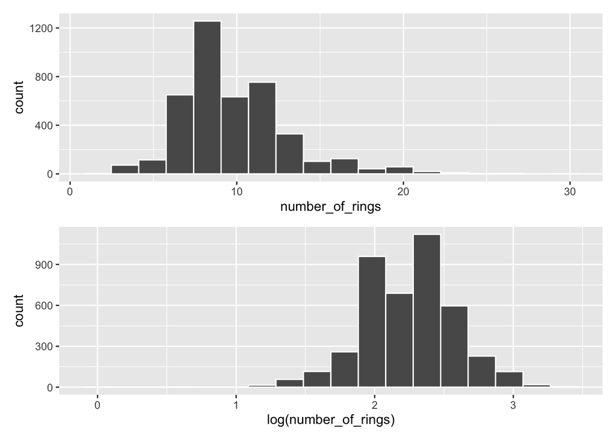

```r
library(patchwork)
p1 <- df |>
  ggplot(aes(number_of_rings))+
  geom_histogram(bins = 18, color='white')
p2 <- df |>
  ggplot(aes(log(number_of_rings)))+
  geom_histogram(bins = 18, color='white')

p1/p2
```

```r
rec_svm2 <- rec_svm |>
  step_log(all_outcomes())

svm <- svm_rbf(mode = "regression",
               engine = "kernlab",
               cost = tune(),
               rbf_sigma = tune(),
               margin = tune())

# wszystkie parametry są gotowe do tuningu
svm_param <- extract_parameter_set_dials(svm)
svm_param
```

```
Collection of 3 parameters for tuning

 identifier      type    object
       cost      cost nparam[+]
  rbf_sigma rbf_sigma nparam[+]
     margin    margin nparam[+]
```

```r
svm_wf2 <- workflow() |>
  add_recipe(rec_svm2) |>
  add_model(svm)
```

```r
cl <- makePSOCKcluster(4)
registerDoParallel(cl)

set.seed(44)
svm_bo <-
  svm_wf2 |>
  tune_bayes(
    resamples = folds,
    metrics = metric,
    initial = 4,
    param_info = svm_param,
    iter = 25
  )

stopCluster(cl)
saveRDS(svm_bo, "svm_bo2.rds")
```

```r
svm_bo <- readRDS("svm_bo2.rds")
show_best(svm_bo, metric = "rmse")
```

```
# A tibble: 5 × 10
   cost rbf_sigma margin .metric .estimator  mean     n std_err .config .iter
  <dbl>     <dbl>  <dbl> <chr>   <chr>      <dbl> <int>   <dbl> <chr>   <int>
1  7.23    0.0249  0.181 rmse    standard   0.190    10 0.00305 Iter15     15
2  8.78    0.0267  0.134 rmse    standard   0.190    10 0.00288 Iter8       8
3  6.25    0.0275  0.132 rmse    standard   0.190    10 0.00291 Iter12     12
4  6.86    0.0296  0.184 rmse    standard   0.190    10 0.00298 Iter13     13
5  5.48    0.0333  0.158 rmse    standard   0.190    10 0.00307 Iter25     25
```

```r
best_params <- select_best(svm_bo, metric = "rmse")

final_wf <- svm_wf2 |>
  finalize_workflow(best_params)

final_wf
```

```
══ Workflow ════════════════════════════════════════════════════════════════════
Preprocessor: Recipe
Model: svm_rbf()

── Preprocessor ────────────────────────────────────────────────────────────────
4 Recipe Steps

• step_best_normalize()
• step_pca()
• step_normalize()
• step_log()

── Model ───────────────────────────────────────────────────────────────────────
Radial Basis Function Support Vector Machine Model Specification (regression)

Main Arguments:
  cost = 7.2269074452528
  rbf_sigma = 0.0249343339049921
  margin = 0.180638210719982

Computational engine: kernlab
```

```r
final_fit <- final_wf |>
  last_fit(split)

final_fit$.metrics
```

```
[[1]]
# A tibble: 2 × 4
  .metric .estimator .estimate .config
  <chr>   <chr>          <dbl> <chr>
1 rmse    standard       0.187 Preprocessor1_Model1
2 rsq     standard       0.675 Preprocessor1_Model1
```

Ponieważ zmienna $y$ została transformowana, to trudno porównywać miary RMSE czy R<sup>2</sup>. Aby to zrobić należy najpierw przekształcić zmienne.

```r
res <- final_fit$.predictions[[1]] |>
  mutate(pred = exp(.pred), obs = exp(number_of_rings))

res |> metric(truth = obs, estimate = pred)
```

```
# A tibble: 2 × 3
  .metric .estimator .estimate
  <chr>   <chr>          <dbl>
1 rmse    standard       2.14
2 rsq     standard       0.588
```

Jak widać dopasowanie jest bardzo podobne (wcale tak być nie musiało).

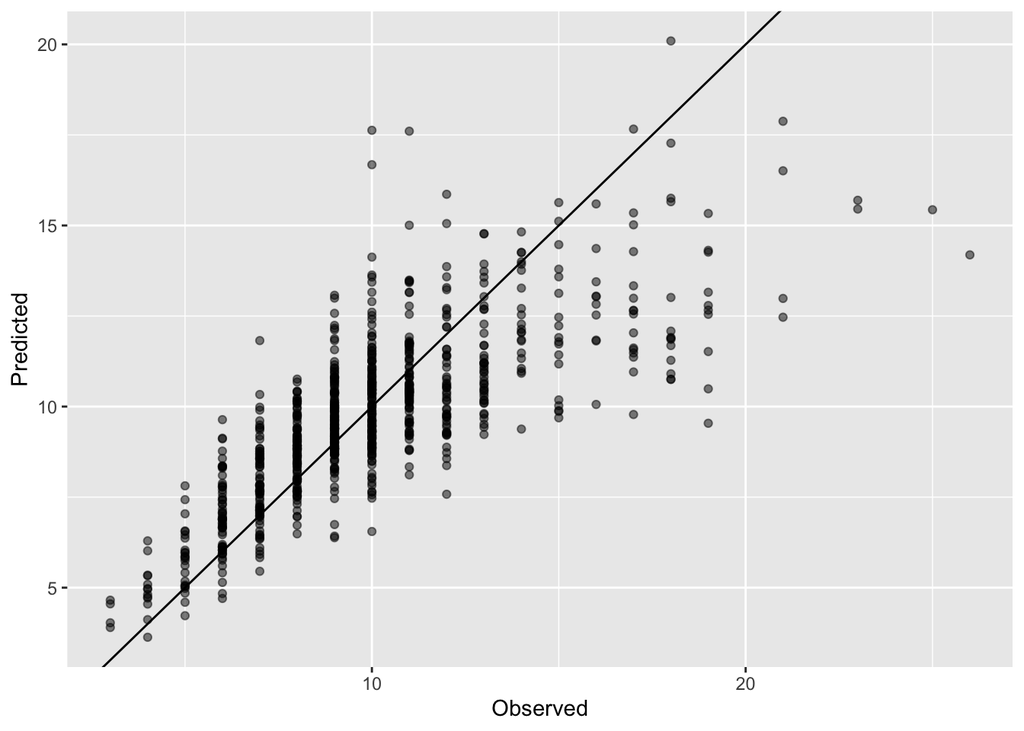

```r
final_fit$.predictions[[1]] |>
  ggplot(aes(x = exp(number_of_rings), y = exp(.pred))) +
  geom_point(alpha=0.5)+
  geom_abline(slope = 1, intercept = 0)+
  labs(y = "Predicted", x = "Observed")
```

# Podsumowanie

Model (nawet ten po transformacji) charakteryzuje się przeciętnym dopasowanie. Z pewnością można byłoby dalej szukać optymalnych modeli do opisu tego zjawiska. Przy okazji modelu z transformacją zmiennej $y$ należy pamiętać, że chcąc uzyskać predykcje liczby ringów dla poszczególnych osobników należy na predykcję z modelu z transformacją nałożyć funkcję $\exp$.